# Rcpp

### Q1b

Since choosing $\lambda$ requires a more formal way to do so, we implement a cross validation function to use.

```r
cv_error <- function(y, x, lambdas, k = 10) {
  # define error metric
  mse <- function(a, b) {
    mean((a - b)^2)
  }

  # vector to store errors for every lambda
  errors <- rep(0, length(lambdas))

  # create a set of random indeces for the folds
  folds <- sample(1:k, size = length(x), replace = TRUE)

  # calculate the error for every lambda
  for (i in 1:length(lambdas)) {
    error <- 0

    # calculate error for every fold
    for (fold in 1:k) {
      # split data into training and test data
      x_test <- x[which(folds == fold)]
      y_test <- y[which(folds == fold)]
      x_train <- x[which(folds != fold)]
      y_train <- y[which(folds != fold)]

      # fit model on the training set and get predictions for the training set
      fit <- meanKRS(y = y_train, x = x_train, x0 = x_test, lam = lambdas[i])

      # calculate the average mse
      error <- error + (mse(fit, y_test) / k)
    }
    errors[i] <- error
  }
  return(errors)
}
```

Find the lambda which has the smallest cross-validation error.

```r
lambdas <- seq(0.001, 0.025, length.out = 50)
errors_krs <- cv_error(y, x, lambdas, 10)
# lambda_min_krs <- lambdas[which.min(cv)]
```

Plot the cross validation error curve and the lambda that gives the smallest error.

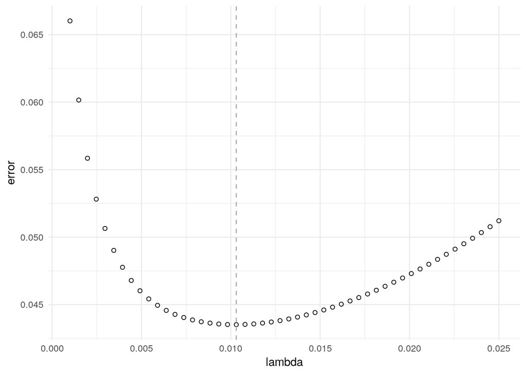

```r
data.frame(lambda = lambdas, error = errors_krs) %>%
  ggplot(aes(x = lambda, y = error)) +
  geom_point(shape=21,size=1.5) +
  geom_vline(aes(xintercept = lambda[which.min(error)]), color = "darkgrey",linetype='dashed')
```

`C` implementation of cross validation.

```cpp
// mean squared error
double mse(const NumericVector a, const NumericVector b){
  return mean(pow((a-b),2));
}

// random wrapper
int randWrapper(const int n){
  return(floor(unif_rand()));
}

// create a sequence of n samples from 0 to k
// [[Rcpp::export(name = "sample_rcpp")]]
NumericVector sample_rcpp(int k, int n){
  NumericVector seq(n);

  // create ordered sequence
  for(int i = 1; i <= k; i++){
    for(int j = i; j <= n; j= j + k){
      seq[j-1] = i-1;
    }
  }

  // randomly shuffle the sequence of indeces
  std::random_shuffle(seq.begin(), seq.end(), randWrapper);
  return seq;
}

// cross validation function

// [[Rcpp::export(name = "cv_meanKRS_cpp")]]
NumericVector cv_meanKRS_cpp(const NumericVector y, const NumericVector x, const NumericVector lambdas, const int k){
  int n = x.size();
  int m = lambdas.size();

  NumericVector errors(m);
  NumericVector folds = sample_rcpp(k, n);

  // iterate over lambdas
  for(int i=0; i < m; i++){
    double error = 0;

    // iterate over folds
    for(int j = 0; j < k; j++){

      // split the data into train and test set
      NumericVector x_test = x[(folds==j)];
      NumericVector x_train = x[(folds!=j)];
      NumericVector y_test = y[(folds==j)];
      NumericVector y_train = y[(folds!=j)];

      // fit model on training data and get
      NumericVector fit = meanKRSR_cpp(y_train, x_train, x_test, lambdas[i]);

      // calculate error for fold
      error = error + mse(fit, y_test)/k;
    }
    errors[i] = error;
  }

  return errors;
}
```

Source the `C` file.

```r
sourceCpp("../code/cv_meanKRS.cpp")
```

Use the `C` implementation to perform the cross validation.

```r
errors_krs_cpp <- cv_meanKRS_cpp(y, x, lambdas, 10)
```

Plot the cross validation error curve.

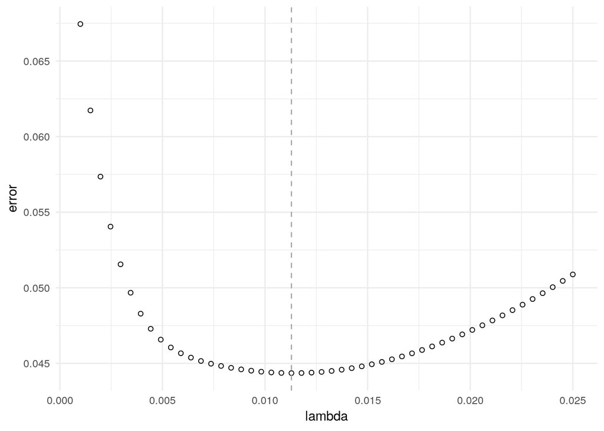

```r
data.frame(lambda = lambdas, error = errors_krs_cpp) %>%
  ggplot(aes(x = lambda, y = error)) +
  geom_point(shape=21, size=1.5) +
  geom_vline(aes(xintercept = lambda[which.min(error)]), color = "darkgrey",linetype='dashed')
```

Compare the efficiency of the `R` and `C` implementations.

```r
microbenchmark(cv_meanKRS_cpp(y, x, lambdas, 5), cv_error(y, x, lambdas, 5), unit = "relative")
```

[output not shown]